# Quick Start Guide for SimpleLink™ CC32xx SDK

#### 6.2.2.2 Browse the example list

- In the IAR-IDE go to the `Help` tab and click on `Information Center`

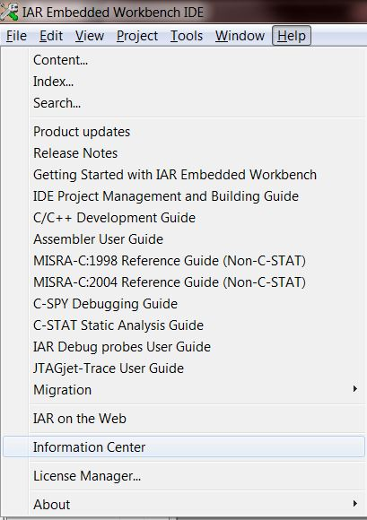

- In the `IAR Information Center for ARM` window, click on `Integrated Solutions`

[figure not shown]

- Scroll down and choose Texas Instruments - Example projects

[figure not shown]

- Click on the **example applications** link.

[figure not shown]

- All the example projects in the SDK that available in IAR are listed in the html page.

[figure not shown]

- Scroll through the page and click on the project you are interested in. In this example we choose to work with network_termianl for the CC3220S based on FreeRTOS.

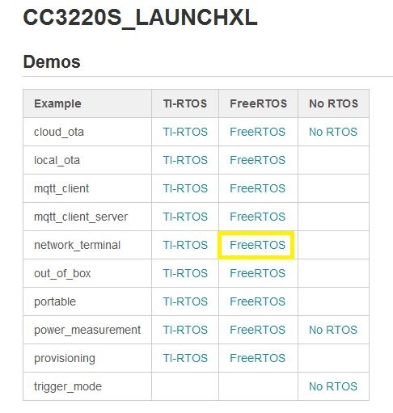

- When prompted, click `Yes` to save a copy of the project workspace in a specific folder, `No` will save the workspace in a default folder.

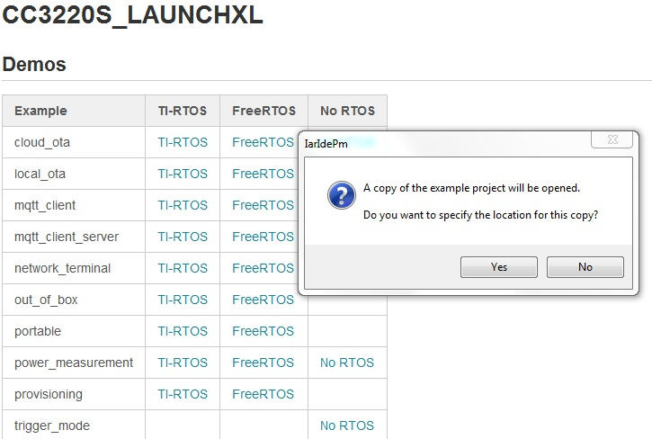

- After clicking `Yes`, browse to the location where you want to save this workspace. Click `Choose`

[figure not shown]

- When importing any example, the related kernel project will be imported automatically

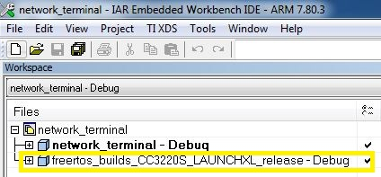

- In order to create a **binary image** in addition to an .out file follow the next steps:
  - right click on the `project name --> options`

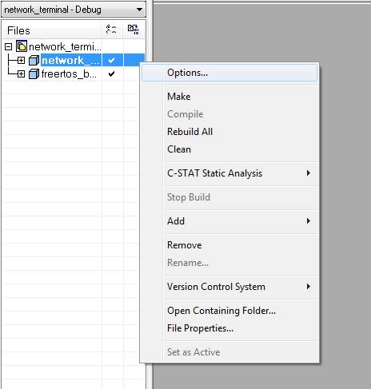

  - On the output converter tab (Highlight in blue), mark the checkbox (in yellow), and change the output format to **binary**.

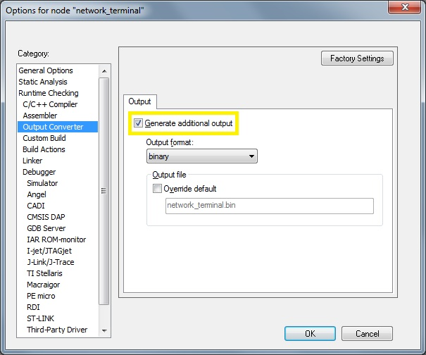

  - Now, hit OK, and later compile. The binary image should reside in: `<your_IAR_workspace>\<IAR_Project location>\Debug\Exe`.
- In order to compile the example and the kernel projects, Choose Project > Make

Make/Build the Example Project Make [(`Project->Make`) `Shortcut F7`]. For RTOS based Projects - Note that the RTOS(kernel) build is a dependent project which is automatically pre-built before the example project builds.  
For noRTOS Projects - There is not RTOS(kernel) build dependent project imported into the workspace

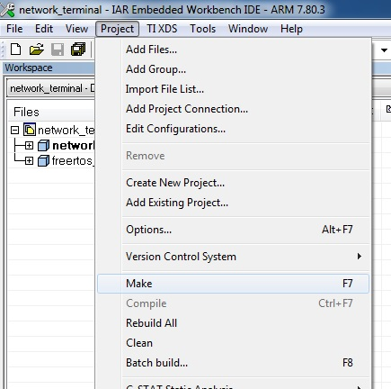

### 6.2.3 Run a debug session

- Select Project -> options from the menu, and select the Debugger category.
- By default, the project Debug settings is configured for TI XDS110, but the user may change them as needed

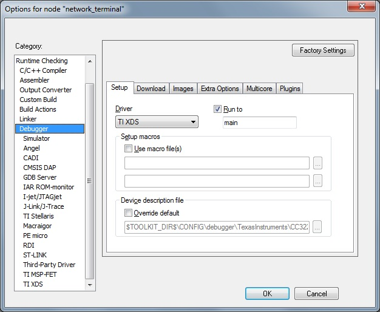

- In case you are working with the CC32xxSF device, check the **Use flash loader(s)** checkbox in the Debugger -> Download tab.

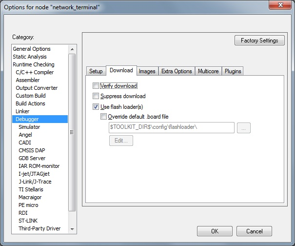

- Go to the TI XDS Category, the settings should be TI XDS110 Emulator as the emulator, and JTAG (4-pin) as the interface
- You can override the path for code composer studio base according to the code composer installation path.

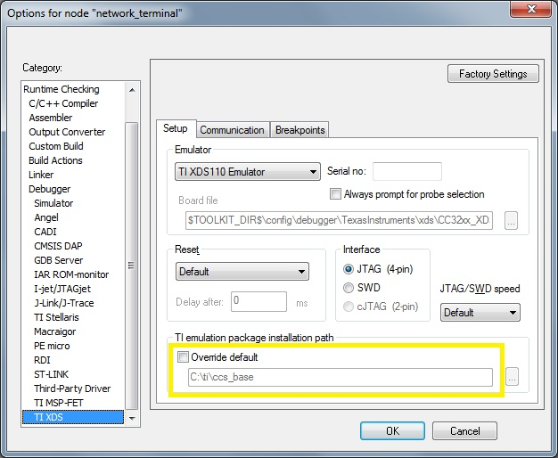

## 6.3 Application User guide

# 7. Quick Start for Makefile Users

The kernel projects, core libs and SDK examples ship makefiles in addition to IDE specific projects.

## 7.1 Update imports.mak

- Update the top level `<SDK_INSTALL_DIR>/imports.mak` to point to actual install locations on the user’s machine

## 7.2 Build Kernel configuration

Building the Kernel can be done in different options according to the requirements.  
The User’s Guide provides details about the various RTOS configuration options. Here is a quick summary in this section

- Open a command prompt. Any Kernel configuration can be built by navigating to the desired directory and running gmake command which is a part of the XDC tools package.
- To build all the NoRTOS, TIRTOS and FreeRTOS config projects

  `cd <SDK_INSTALL_PATH>\kernel`

  `<XDCTOOLS_INSTALL_PATH>\gmake.exe`

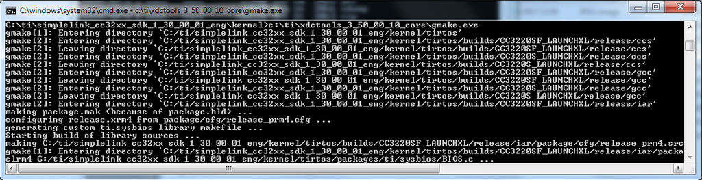

- To build only TIRTOS config project

  `cd <SDK_INSTALL_PATH>\kernel`

  Debug: `<XDCTOOLS_INSTALL_PATH>\gmake.exe tirtos-debug`

  Release: `<XDCTOOLS_INSTALL_PATH>\gmake.exe tirtos-release`
- To build only FreeRTOS config project

  `cd <SDK_INSTALL_PATH>\kernel`

  Release: `<XDCTOOLS_INSTALL_PATH>\gmake.exe freertos-release`
- To build only NoRTOS config project

  `cd <SDK_INSTALL_PATH>\kernel`

  Release: `<XDCTOOLS_INSTALL_PATH>\gmake.exe nortos-release`
- To build only specific config project

  `cd <SDK_INSTALL_PATH>\kernel\<OS>\builds\<Board variant>\<release or debug>\<Compiler>`  
  Example: `cd C:\ti\simplelink_cc32xx_sdk_1_02_00_01_eng\kernel\freertos\builds\CC3220SF_LAUNCHXL\release\gcc`

  `<XDCTOOLS_INSTALL_PATH>\gmake.exe`

## 7.3 Build Core libs

The SDK include Host Driver, MQTT or OTA libs that can be compiled after changes.

- To build Host Driver lib

  `cd <SDK_INSTALL_PATH>\source\ti\drivers\net\wifi`

  Release: `<XDCTOOLS_INSTALL_PATH>\gmake.exe`

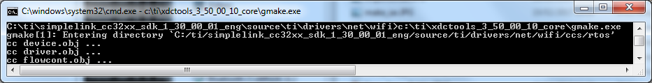

- To build MQTT lib

  `cd <SDK_INSTALL_PATH>\source\ti\net\mqtt`

  Release: `<XDCTOOLS_INSTALL_PATH>\gmake.exe`

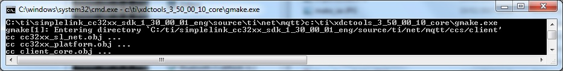

- To build OTA lib

  `cd <SDK_INSTALL_PATH>\source\ti\net\ota`

  Release: `<XDCTOOLS_INSTALL_PATH>\gmake.exe`

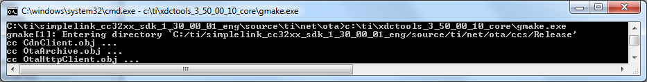

## 7.4 Build the project

- Identify the makefile for the project and build it.  
  For Example `<SDK_INSTALL_DIR>/examples/rtos/CC3220SF_LAUNCHXL/demos/network_terminal/freertos/gcc`

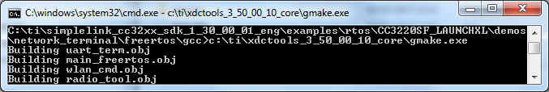

# 8. Quick Start for Linux Users

When using Linux machine the installation steps for the SDK and IDE’s are the same as in windows.

- Quick Start for CCS IDE can be found in QuickStart for CCS IDE paragraph.
- Quick Start for Makefile Users can be found in Quick Start for Makefile Users paragraph.

  > Note: When using Makefile in Linux machine, instead of using the gmake command, just use make.  
  > For Example:

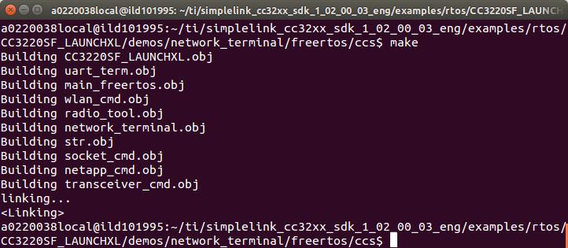

# 9. Application User guide